# Factor Analysis (Wave 2) – Dads Matter

Michael Wu

2023-10-24

# 1 Recommendations

- MOTHER AND FATHER INVOLVEMENT WITH INFANT (`mfi`): Good CFA fit and use factor scores generated from CFA model
- PARENT-CHILD CONFLICT TACTICS SCALES (`pccts`): Use scoring rule and sum scores (The midpoints are the same as the response category numbers for categories 0, 1, and 2. For category 3 (3–5 times) the midpoint is 4, for category 4 (6–10 times) it is 8, for category 5 (11–20 times) it is 15, and for category 6 (More than 20 times in the past year) we suggest using 25 as the midpoint.)
- CHILD NEGLECT (`neg`): Use scoring rule and sum scores
- DEPRESSION: CIDI-SF: Use scoring rules
- PARENTING ALLIANCE INVENTORY (`pai`):
  - Mother’s self-report:
    - Questionable CFA model fit with the theory-based structure
    - Good model fit with the empirically-driven structure (with 5 items deleted as suggested by rules in Kwan’s paper) but not so explainable factors
  - Father’s self-report: Questionable CFA model fit in all my modeling attempts
- RELATIONSHIP QUALITY (`rq`):
  - Good CFA fit for mother’s report and use factor score
  - Not so good CFA fit for father’s report, model fit improved by removing one questionable item
- CONFLICT TACTICS SCALE (`cts`): Use item-pair sum/average score

# 2 Introduction

**Evidence of construct validity:**

**Evidence of internal consistency:**

- Cronbach’s Alpha (α) is a measure of internal consistency reliability that assesses the extent to which items within a test or questionnaire are inter-related, calculated as the mean of all possible split-half reliabilities, corrected for test length.
- McDonald’s Omega (ω) is a measure of internal consistency reliability based on the factor structure of the test, calculated by decomposing the total variance of the items into the variance due to a general factor, the variance due to group factors, and the unique variance, providing a more accurate estimate of reliability when the assumption of unidimensionality is violated.
- Simply put, α is computed based on the raw data, and ω is computed from the CFA. In practice, we would often want to calculate a reliability coefficient for each subscale at each wave when we build a multi-factor CFA, besides a general reliability coefficient for the entire construct.

# 3 Data Preparation

```r
# load library
library(tidyverse)
library(lavaan)
library(psych)
source(here::here("R/functions.R"))

# load data
dat_s <- read_csv(here::here("data/dads_matter_fa.csv"))
```

**_m: mother report**

**_f: father report**

# 4 MOTHER AND FATHER INVOLVEMENT WITH INFANT

Like in Wave 1, models on mothers involvement (either rated by mothers themselves or fathers) require two added residual covariance terms between `mfi3` (Read stories to (CHILD)) and `mfi4` (Tell stories to (CHILD)), and between `mfi7` (Hug or show physical affection to (CHILD)) and `mfi8` (Put (CHILD) to bed).

Unlike in Wave 1, models on fathers involvement (either rated by fathers themselves or mothers) only require one residual covariance term between `mfi3` (Read stories to (CHILD)) and `mfi4` (Tell stories to (CHILD)).

## 4.1 Father’s involvement with children (reported by mothers)

```r
cfa_mfi_m <- '
  mfi_m_2 =~ mfi1.1_2 + mfi2.1_2 + mfi3.1_2 + mfi4.1_2 +
           mfi5.1_2 + mfi6.1_2 + mfi7.1_2 + mfi8.1_2

  mfi3.1_2 ~~ mfi4.1_2
  # mfi7.1_2 ~~ mfi8.1_2
'

fit_mfi_m <- cfa(cfa_mfi_m,
                 data = dat_s,
                 std.lv = TRUE,
                 missing = "FIML",
                 parameterization = "theta"
                 )
```

**Click to see full model results:**

```r
summary(fit_mfi_m, fit.measures = TRUE, standardized = TRUE)
```

```
## lavaan 0.6.15 ended normally after 46 iterations
##
##   Estimator                                         ML
##   Optimization method                           NLMINB
##   Number of model parameters                        25
##
##                                                   Used       Total
##   Number of observations                           149         204
##   Number of missing patterns                        12
##
## Model Test User Model:
##
##   Test statistic                                18.420
##   Degrees of freedom                                19
##   P-value (Chi-square)                           0.495
##
## Model Test Baseline Model:
##
##   Test statistic                               242.558
##   Degrees of freedom                                28
##   P-value                                        0.000
##
## User Model versus Baseline Model:
##
##   Comparative Fit Index (CFI)                    1.000
##   Tucker-Lewis Index (TLI)                       1.004
##
##   Robust Comparative Fit Index (CFI)             1.000
##   Robust Tucker-Lewis Index (TLI)                1.006
##
## Loglikelihood and Information Criteria:
##
##   Loglikelihood user model (H0)              -2203.772
##   Loglikelihood unrestricted model (H1)      -2194.562
##
##   Akaike (AIC)                                4457.544
##   Bayesian (BIC)                              4532.643
##   Sample-size adjusted Bayesian (SABIC)       4453.525
##
## Root Mean Square Error of Approximation:
```

[output cut: 48 more lines]

```
##    .mfi7.1_2          6.906    0.056  124.161    0.000    6.906   10.172
##    .mfi8.1_2          6.705    0.086   78.246    0.000    6.705    6.410
##     mfi_m_2           0.000                               0.000    0.000
##
## Variances:
##                    Estimate  Std.Err  z-value  P(>|z|)   Std.lv  Std.all
##    .mfi1.1_2          2.257    0.302    7.477    0.000    2.257    0.765
##    .mfi2.1_2          1.917    0.544    3.523    0.000    1.917    0.396
##    .mfi3.1_2          4.423    0.734    6.025    0.000    4.423    0.624
##    .mfi4.1_2          4.537    0.751    6.039    0.000    4.537    0.604
##    .mfi5.1_2          5.179    0.665    7.785    0.000    5.179    0.832
##    .mfi6.1_2          4.945    0.592    8.356    0.000    4.945    0.952
##    .mfi7.1_2          0.461    0.053    8.631    0.000    0.461    1.000
##    .mfi8.1_2          1.044    0.123    8.478    0.000    1.044    0.955
##     mfi_m_2           1.000                               1.000    1.000
```

```r
# modindices(fit_mfi_m, sort = TRUE, maximum.number = 5)
```

**Reliability:**

```r
get_rel(model = fit_mfi_m,
        data = dat_s |> select(mfi1.1_2:mfi8.1_2))
```

```
## [1] "Cronbach's Alpha is 0.696, which is Acceptable; McDonald's Omega is 0.662, which is Acceptable."
```

## 4.2 Mother’s involvement with children (reported by mothers)

```r
cfa_mfia_m <- '
  mfia_m_2 =~ mfi1a.1_2 + mfi2a.1_2 + mfi3a.1_2 + mfi4a.1_2 +
           mfi5a.1_2 + mfi6a.1_2 + mfi7a.1_2 + mfi8a.1_2

   mfi3a.1_2 ~~ mfi4a.1_2
   mfi7a.1_2 ~~ mfi8a.1_2
'

fit_mfia_m <- cfa(cfa_mfia_m,
                 data = dat_s,
                 std.lv = TRUE, missing = "FIML",
                 parameterization = "theta"
                 )
```

**Click to see full model results:**

```r
summary(fit_mfia_m, fit.measures = TRUE, standardized = TRUE)
```

```
## lavaan 0.6.15 ended normally after 39 iterations
##
##   Estimator                                         ML
##   Optimization method                           NLMINB
##   Number of model parameters                        26
##
##                                                   Used       Total
##   Number of observations                           148         204
##   Number of missing patterns                         4
##
## Model Test User Model:
##
##   Test statistic                                28.898
##   Degrees of freedom                                18
##   P-value (Chi-square)                           0.050
##
## Model Test Baseline Model:
##
##   Test statistic                               292.990
##   Degrees of freedom                                28
##   P-value                                        0.000
##
## User Model versus Baseline Model:
##
##   Comparative Fit Index (CFI)                    0.959
##   Tucker-Lewis Index (TLI)                       0.936
##
##   Robust Comparative Fit Index (CFI)             0.959
##   Robust Tucker-Lewis Index (TLI)                0.937
##
## Loglikelihood and Information Criteria:
##
##   Loglikelihood user model (H0)              -2468.718
##   Loglikelihood unrestricted model (H1)      -2454.270
##
##   Akaike (AIC)                                4989.437
##   Bayesian (BIC)                              5067.364
##   Sample-size adjusted Bayesian (SABIC)       4985.084
##
## Root Mean Square Error of Approximation:
```

[output cut: 50 more lines]

```
##    .mfi7a.1_2         6.642    0.102   65.098    0.000    6.642    5.351
##    .mfi8a.1_2         5.108    0.190   26.859    0.000    5.108    2.208
##     mfia_m_2          0.000                               0.000    0.000
##
## Variances:
##                    Estimate  Std.Err  z-value  P(>|z|)   Std.lv  Std.all
##    .mfi1a.1_2         2.376    0.461    5.158    0.000    2.376    0.470
##    .mfi2a.1_2         3.000    0.524    5.722    0.000    3.000    0.512
##    .mfi3a.1_2         3.730    0.557    6.695    0.000    3.730    0.647
##    .mfi4a.1_2         4.897    0.668    7.333    0.000    4.897    0.710
##    .mfi5a.1_2         4.227    0.588    7.187    0.000    4.227    0.657
##    .mfi6a.1_2         4.600    0.551    8.352    0.000    4.600    0.940
##    .mfi7a.1_2         1.452    0.173    8.399    0.000    1.452    0.942
##    .mfi8a.1_2         4.546    0.561    8.111    0.000    4.546    0.849
##     mfia_m_2          1.000                               1.000    1.000
```

```r
# modindices(fit_mfia_m, sort = TRUE, maximum.number = 5)
```

**Reliability:**

```r
get_rel(model = fit_mfia_m,
        data = dat_s |> select(mfi1a.1_2:mfi8a.1_2))
```

```
## [1] "Cronbach's Alpha is 0.751, which is Acceptable; McDonald's Omega is 0.72, which is Acceptable."
```

```r
cfa_mfi_f <- '
  mfi_f_2 =~ mfi1.2_2 + mfi2.2_2 + mfi3.2_2 + mfi4.2_2 +
           mfi5.2_2 + mfi6.2_2 + mfi7.2_2 + mfi8.2_2

  mfi3.2_2 ~~ mfi4.2_2
  # mfi7.2_2 ~~ mfi8.2_2
'

fit_mfi_f <- cfa(cfa_mfi_f,
                 data = dat_s,
                 std.lv = TRUE, missing = "FIML",
                 parameterization = "theta"
                 )
```

**Click to see full model results:**

```r
summary(fit_mfi_f, fit.measures = TRUE, standardized = TRUE)
```

```
## lavaan 0.6.15 ended normally after 42 iterations
##
##   Estimator                                         ML
##   Optimization method                           NLMINB
##   Number of model parameters                        25
##
##                                                   Used       Total
##   Number of observations                           168         204
##   Number of missing patterns                        10
##
## Model Test User Model:
##
##   Test statistic                                23.670
##   Degrees of freedom                                19
##   P-value (Chi-square)                           0.209
##
## Model Test Baseline Model:
##
##   Test statistic                               294.054
##   Degrees of freedom                                28
##   P-value                                        0.000
##
## User Model versus Baseline Model:
##
##   Comparative Fit Index (CFI)                    0.982
##   Tucker-Lewis Index (TLI)                       0.974
##
##   Robust Comparative Fit Index (CFI)             0.984
##   Robust Tucker-Lewis Index (TLI)                0.977
##
## Loglikelihood and Information Criteria:
##
##   Loglikelihood user model (H0)              -2407.602
##   Loglikelihood unrestricted model (H1)      -2395.767
##
##   Akaike (AIC)                                4865.204
##   Bayesian (BIC)                              4943.303
##   Sample-size adjusted Bayesian (SABIC)       4864.148
##
## Root Mean Square Error of Approximation:
```

[output cut: 48 more lines]

```
##    .mfi7.2_2          6.904    0.035  196.396    0.000    6.904   15.198
##    .mfi8.2_2          6.390    0.106   60.245    0.000    6.390    4.662
##     mfi_f_2           0.000                               0.000    0.000
##
## Variances:
##                    Estimate  Std.Err  z-value  P(>|z|)   Std.lv  Std.all
##    .mfi1.2_2          1.901    0.240    7.911    0.000    1.901    0.733
##    .mfi2.2_2          1.518    0.279    5.441    0.000    1.518    0.449
##    .mfi3.2_2          2.774    0.479    5.791    0.000    2.774    0.488
##    .mfi4.2_2          4.081    0.573    7.126    0.000    4.081    0.652
##    .mfi5.2_2          4.039    0.535    7.549    0.000    4.039    0.663
##    .mfi6.2_2          5.564    0.611    9.100    0.000    5.564    0.989
##    .mfi7.2_2          0.191    0.022    8.860    0.000    0.191    0.926
##    .mfi8.2_2          1.790    0.199    8.996    0.000    1.790    0.953
##     mfi_f_2           1.000                               1.000    1.000
```

```r
# modindices(fit_mfi_f, sort = TRUE, maximum.number = 5)
```

**Reliability:**

```r
get_rel(model = fit_mfi_f,
        data = dat_s |> select(mfi1.2_2:mfi8.2_2))
```

```
## [1] "Cronbach's Alpha is 0.701, which is Acceptable; McDonald's Omega is 0.681, which is Acceptable."
```

## 4.4 Mother’s involvement with children (reported by fathers)

```r
cfa_mfia_f <- '
  mfia_f_2 =~ mfi1a.2_2 + mfi2a.2_2 + mfi3a.2_2 + mfi4a.2_2 +
           mfi5a.2_2 + mfi6a.2_2 + mfi7a.2_2 + mfi8a.2_2

 mfi3a.2_2 ~~ mfi4a.2_2
 mfi7a.2_2 ~~ mfi8a.2_2
'

fit_mfia_f <- cfa(cfa_mfia_f,
                 data = dat_s,
                 std.lv = TRUE, missing = "FIML",
                 parameterization = "theta"
                 )
```

**Click to see full model results:**

```r
summary(fit_mfia_f, fit.measures = TRUE, standardized = TRUE)
```

```
## lavaan 0.6.15 ended normally after 33 iterations
##
##   Estimator                                         ML
##   Optimization method                           NLMINB
##   Number of model parameters                        26
##
##                                                   Used       Total
##   Number of observations                           169         204
##   Number of missing patterns                         2
##
## Model Test User Model:
##
##   Test statistic                                26.293
##   Degrees of freedom                                18
##   P-value (Chi-square)                           0.093
##
## Model Test Baseline Model:
##
##   Test statistic                               373.339
##   Degrees of freedom                                28
##   P-value                                        0.000
##
## User Model versus Baseline Model:
##
##   Comparative Fit Index (CFI)                    0.976
##   Tucker-Lewis Index (TLI)                       0.963
##
##   Robust Comparative Fit Index (CFI)             0.976
##   Robust Tucker-Lewis Index (TLI)                0.962
##
## Loglikelihood and Information Criteria:
##
##   Loglikelihood user model (H0)              -2806.499
##   Loglikelihood unrestricted model (H1)      -2793.353
##
##   Akaike (AIC)                                5664.999
##   Bayesian (BIC)                              5746.376
##   Sample-size adjusted Bayesian (SABIC)       5664.052
##
## Root Mean Square Error of Approximation:
```

[output cut: 50 more lines]

```
##    .mfi7a.2_2         6.562    0.103   63.648    0.000    6.562    4.896
##    .mfi8a.2_2         4.976    0.175   28.384    0.000    4.976    2.183
##     mfia_f_2          0.000                               0.000    0.000
##
## Variances:
##                    Estimate  Std.Err  z-value  P(>|z|)   Std.lv  Std.all
##    .mfi1a.2_2         2.598    0.374    6.950    0.000    2.598    0.491
##    .mfi2a.2_2         2.200    0.345    6.370    0.000    2.200    0.429
##    .mfi3a.2_2         3.202    0.435    7.354    0.000    3.202    0.573
##    .mfi4a.2_2         3.085    0.437    7.055    0.000    3.085    0.519
##    .mfi5a.2_2         4.673    0.544    8.588    0.000    4.673    0.779
##    .mfi6a.2_2         4.873    0.557    8.751    0.000    4.873    0.837
##    .mfi7a.2_2         1.564    0.177    8.850    0.000    1.564    0.871
##    .mfi8a.2_2         3.822    0.454    8.418    0.000    3.822    0.736
##     mfia_f_2          1.000                               1.000    1.000
```

```r
# modindices(fit_mfia_f, sort = TRUE, maximum.number = 5)
```

**Reliability:**

```r
get_rel(model = fit_mfia_f,
        data = dat_s |> select(mfi1a.2_2:mfi8a.2_2))
```

```
## [1] "Cronbach's Alpha is 0.804, which is Good; McDonald's Omega is 0.783, which is Acceptable."
```

# 5 PARENT-CHILD CONFLICT TACTICS SCALES

Straus, M. A., Hamby, S. L., Finkelhor, D., Moore, D. W., & Runyan, D. (1998). Identification of child maltreatment with the Parent-Child Conflict Tactics Scales: Development and psychometric data for a national sample of American parents. Child abuse & neglect, 22(4), 249-270. https://doi.org/10.1016/S0145-2134(97)00174-9

This scale has existing scoring rules (https://emerge.ucsd.edu/r_3dl0y438y6yhvyo/):

The scale is scored by adding the midpoints for the response categories chosen by the participant. The midpoints are the same as the response category numbers for categories 0, 1, and 2. For category 3 (3–5 times) the midpoint is 4, for category 4 (6–10 times) it is 8, for category 5 (11–20 times) it is 15, and for category 6 (More than 20 times in the past year) we suggest using 25 as the midpoint.

As described in the original paper, some events measured by the scale are very rare, thus resulting a very skewed distribution: “The extremely skewed distributions drastically lower the correlation between the items and reduces alpha because alpha is a function of the size of the correlations between items. In addition the severe assault items do not meet other assumptions such as equal variance.” Therefore, we are following the original recommended scoring rules instead of building new CFAs on this established measure (which failed to build due to highly skewed data).

```r
dat_s <- dat_s |>
  mutate(
    across(starts_with("pccts"), ~ case_when(
      .x == 3  ~ 4,
      .x == 4  ~ 8,
      .x == 5  ~ 15,
      .x == 6  ~ 25,
      TRUE     ~ .x
    ))
  )
```

# 6 CHILD NEGLECT

For this measure, the CFA models also failed to build due to highly skewed data. Similar to PCCTS, we can take a sum of these variables as the total instances of child neglect, instead of treating it as a latent construct.

# 7 DEPRESSION: CIDI-SF

This scale has conditional questions that prompt you to skip a few questions based on your choice in previous questions. Therefore, some later questions only have very few respondent, so CFA is not a good option for this scale. As suggested by Aaron, we are adopting the following scoring rules:

| Variable | Description |
| --- | --- |
| zDysphoria_f | Dysphoria subscale; but dichotomized due to scale |
| AnhedoniaScale_f | 0-8 Anhedonia Scale, a 3 or higher meets criteria for depression |
| zAnhedonia_f | Dichotomized so that 3 or greater is = 1 |
| zMajorDepression_f | MD indicated if either zDysphoria OR zAnhedonia is a 1 |

```r
#CIDI Scoring

#zDysphoria
dat_s <- dat_s %>%
  mutate(zDysphoria = ifelse(cidi1.1_2 == 1 & cidi2.1_2 < 4 &
                               cidi3.1_2 < 3 & cidi4.1_2 == 1,
                             1, 0))
#AnhedoniaScale
dat_s <- dat_s %>% mutate(fac1 = ifelse(cidi5.1_2 == 1 & cidi6.1_2 < 3, 1, 0),
                          fac2 = ifelse(cidi7.1_2 < 3, 1, 0),
                          fac3 = ifelse(cidi8.1_2 == 1, 1, 0),
                          fac4 = ifelse(cidi9.1_2 < 4 & cidi9a.1_2 > 9, 1, 0),
                          fac5 = ifelse(cidi10.1_2 == 1 & cidi10a.1_2 < 3, 1, 0),
                          fac6 = ifelse(cidi11.1_2 == 1, 1, 0),
                          fac7 = ifelse(cidi12.1_2 == 1, 1, 0),
                          fac8 = ifelse(cidi13.1_2 == 1, 1, 0)) %>%
  rowwise() %>%
  mutate(AnhedoniaScale = sum(fac1, fac2, fac3, fac4, fac5, fac6, fac7, fac8, na.rm = TRUE))

#zAnhedonia
dat_s <- dat_s %>%
  mutate(zAnhedonia = ifelse(AnhedoniaScale > 2, 1, 0))

#zMajorDep
dat_s <- dat_s %>%
  mutate(zMajorDep = ifelse(zDysphoria == 1 | zAnhedonia == 1, 1, 0))
```

# 8 PARENTING ALLIANCE INVENTORY

## 8.1 Mother’s self-report parenting alliance with father

Based on Aaron’s notes, there seem to be two theory-based factors for this measure: alliance with partner and shared alliance. However, the CFA model for mother’s self-report does not have acceptable fit indices and data-driven modification indices do not seem to suggest theoretically sound alternative links.

```r
# Theory-based 2-factor model does not fit well and there is no theoretical justification for the links suggested by modification indices

cfa_pai_m <- '
  pai_shared_m_2 =~ pai5.1_2 + pai7.1_2 + pai9.1_2 + pai12.1_2 + pai17.1_2 + pai23.1_2 + pai24.1_2 + pai25.1_2
  pai_partner_m_2 =~ pai13.1_2 + pai14.1_2 + pai19.1_2 + pai20.1_2 + pai21.1_2 + pai27.1_2 + pai27.1_2 + pai28.1_2 + pai29.1_2
'


fit_pai_m <- cfa(cfa_pai_m,
                 data = dat_s,
                 std.lv = TRUE, missing = "FIML",
                 parameterization = "theta"
                 )
```

**Click to see full model results:**

```r
summary(fit_pai_m, fit.measures = TRUE, standardized = TRUE)
```

```
## lavaan 0.6.15 ended normally after 73 iterations
##
##   Estimator                                         ML
##   Optimization method                           NLMINB
##   Number of model parameters                        49
##
##                                                   Used       Total
##   Number of observations                           201         204
##   Number of missing patterns                         6
##
## Model Test User Model:
##
##   Test statistic                               321.023
##   Degrees of freedom                               103
##   P-value (Chi-square)                           0.000
##
## Model Test Baseline Model:
##
##   Test statistic                              1500.375
##   Degrees of freedom                               120
##   P-value                                        0.000
##
## User Model versus Baseline Model:
##
##   Comparative Fit Index (CFI)                    0.842
##   Tucker-Lewis Index (TLI)                       0.816
##
##   Robust Comparative Fit Index (CFI)             0.834
##   Robust Tucker-Lewis Index (TLI)                0.807
##
## Loglikelihood and Information Criteria:
##
##   Loglikelihood user model (H0)              -2111.433
##   Loglikelihood unrestricted model (H1)      -1950.922
##
##   Akaike (AIC)                                4320.867
##   Bayesian (BIC)                              4482.729
##   Sample-size adjusted Bayesian (SABIC)       4327.489
##
## Root Mean Square Error of Approximation:
```

[output cut: 75 more lines]

```
##    .pai12.1_2         0.199    0.026    7.728    0.000    0.199    0.455
##    .pai17.1_2         0.242    0.027    9.073    0.000    0.242    0.587
##    .pai23.1_2         0.158    0.020    7.850    0.000    0.158    0.470
##    .pai24.1_2         0.154    0.017    8.853    0.000    0.154    0.516
##    .pai25.1_2         0.197    0.023    8.575    0.000    0.197    0.470
##    .pai13.1_2         0.080    0.012    6.859    0.000    0.080    0.376
##    .pai14.1_2         0.363    0.043    8.378    0.000    0.363    0.692
##    .pai19.1_2         0.095    0.013    7.432    0.000    0.095    0.467
##    .pai20.1_2         0.271    0.031    8.719    0.000    0.271    0.567
##    .pai21.1_2         0.324    0.039    8.367    0.000    0.324    0.651
##    .pai27.1_2         0.624    0.071    8.740    0.000    0.624    0.863
##    .pai28.1_2         0.156    0.020    7.961    0.000    0.156    0.563
##    .pai29.1_2         0.171    0.021    8.176    0.000    0.171    0.465
##     pai_shared_m_2    1.000                               1.000    1.000
##     pai_partnr_m_2    1.000                               1.000    1.000
```

```r
# modindices(fit_pai_m, sort = TRUE, maximum.number = 5)
```

We then re-conducted an EFA model to explore the potential factor structure. Based on the eigenvalues, 2-factor or 3-factor model seems to be a better solution.

```r
vec <- grep("^pai\\d+\\.1_2$", names(dat_s), value = T)

# Extract numbers using regular expression
numbers <- as.numeric(gsub("pai([0-9]+)\\..*", "\\1", vec))

# Order the vector based on the extracted numbers
sorted_vec <- vec[order(numbers)]

efa_pai_m <- lavaan::efa(dat_s,
                 ov.names = sorted_vec,
                 nfactors = 1:3
                 )
```

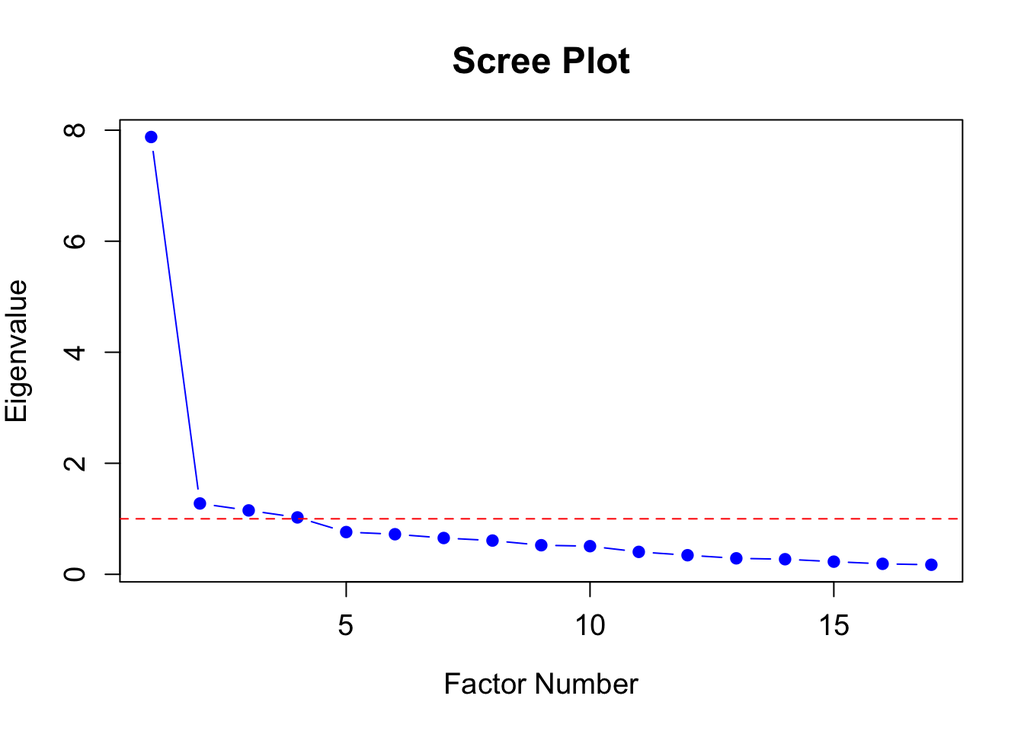

```r
# Eigenvalues extracted from the fitted lavaan EFA model
eigenvalues <- c(7.877, 1.276, 1.151, 1.025, 0.761, 0.722, 0.654, 0.608, 0.524, 0.507, 0.404, 0.344, 0.288, 0.272, 0.228, 0.189, 0.172)

# Create a Scree Plot
plot(eigenvalues, type = "b", pch = 19, main = "Scree Plot",
     xlab = "Factor Number", ylab = "Eigenvalue", col = "blue",
     cex.lab = 1.2, cex.axis = 1.2, cex.main = 1.5)

# Add a reference line at y = 1
abline(h = 1, col = "red", lty = 2)
```

**Click to see full model results:**

```r
# model stats
summary(efa_pai_m)
```

```
##
##   Estimator                                         ML
##   Rotation method                       GEOMIN OBLIQUE
##   Geomin epsilon                                 0.001
##   Rotation algorithm (rstarts)                GPA (30)
##   Standardized metric                             TRUE
##   Row weights                                     None
##
##                                                   Used       Total
##   Number of observations                           158         204
##
## Overview models:
##                     aic      bic    sabic   chisq  df pvalue   cfi rmsea
##   nfactors = 1 3986.339 4090.468 3982.841 425.979 119      0 0.783 0.128
##   nfactors = 2 3900.149 4053.279 3895.005 307.788 103      0 0.855 0.112
##   nfactors = 3 3810.751 4009.819 3804.063 188.390  88      0 0.929 0.085
##
## Eigenvalues correlation matrix:
##
##     ev1     ev2     ev3     ev4     ev5     ev6     ev7     ev8     ev9    ev10
##   7.877   1.276   1.151   1.025   0.761   0.722   0.654   0.608   0.524   0.507
##    ev11    ev12    ev13    ev14    ev15    ev16    ev17
##   0.404   0.344   0.288   0.272   0.228   0.189   0.172
##
## Number of factors:  1
##
## Standardized loadings: (* = significant at 1% level)
##
##               f1       unique.var   communalities
## pai5.1_2   0.712*           0.493           0.507
## pai7.1_2   0.698*           0.513           0.487
## pai9.1_2   0.621*           0.615           0.385
## pai12.1_2  0.695*           0.517           0.483
## pai13.1_2  0.730*           0.466           0.534
## pai14.1_2  0.542*           0.706           0.294
## pai17.1_2  0.684*           0.532           0.468
## pai19.1_2  0.694*           0.519           0.481
## pai20.1_2  0.680*           0.538           0.462
## pai21.1_2  0.573*           0.671           0.329
## pai23.1_2  0.685*           0.531           0.469
```

[output cut: 68 more lines]

```
## pai28.1_2      .*  0.541*                   0.514           0.486
## pai29.1_2          0.320*  0.563*           0.465           0.535
##
##                               f3    f1    f2 total
## Sum of sq (obliq) loadings 4.112 2.607 2.458 9.178
## Proportion of total        0.448 0.284 0.268 1.000
## Proportion var             0.242 0.153 0.145 0.540
## Cumulative var             0.242 0.395 0.540 0.540
##
## Factor correlations: (* = significant at 1% level)
##
##        f1      f2      f3
## f1  1.000
## f2  0.381*  1.000
## f3  0.671*  0.436*  1.000
```

As suggested in Kwan’s paper, specific items were retained based on the criteria for small sample sizes suggested by Worthington and Whittaker (2006). They suggest that EFA can be adequate if: (a) all items contain communalities higher than .5, indicating the proportion of each item’s variance explained by the factors, (b) items’ factor loadings are greater than 0.4 without high cross‐loading items, and (c) all factors have at least three items.

The 2-factor models does not fit well. After deleting 5 items based on the above rules, the 3-factor CFA model has an acceptable fit and good reliability. Factor 1 can be cooperation between parents, Factor 2 can be views about the other parent’s parenting skills, Factor 3 seems to encompass lots of different things and is hard to define.

*Factor 1:*

- pai12: When there is a problem with our child, we work out a good solution together.
- pai23: My child’s father and I communicate well about our child
- pai24: Talking to my child’s father about our child is something I look forward to.

*Factor 2:*

- pai13: I believe my child’s father is a good parent.
- pai19: My child’s father cares about our child.
- pai28: My child’s father pays a great deal of attention to our child.

*Factor 3:*

- pai7: My child’s father and I have the same goals for our child.
- pai9: My child’s father and I agree on what our child should and should not be permitted to do.
- pai14: I learn how to better manage my child by watching his/her father manage him/her.
- pai20: I feel good about my child’s father’s judgment about what is right for our child.
- pai21: My child’s father makes my job of being a parent easier.
- pai25: My child’s father and I are a good team.

```r
cfa_pai_m <- '
  pai_f1_m_2 =~ pai12.1_2 + pai23.1_2 + pai24.1_2
  pai_f2_m_2 =~ pai13.1_2 + pai19.1_2 + pai28.1_2
  pai_f3_m_2 =~ pai7.1_2 + pai9.1_2 + pai14.1_2 + pai20.1_2 + pai21.1_2 + pai25.1_2
'

fit_pai_m <- cfa(cfa_pai_m,
                 data = dat_s,
                 std.lv = TRUE, missing = "FIML",
                 parameterization = "theta"
                 )
```

**Click to see full model results:**

```r
summary(fit_pai_m, fit.measures = TRUE, standardized = TRUE)
```

```
## lavaan 0.6.15 ended normally after 71 iterations
##
##   Estimator                                         ML
##   Optimization method                           NLMINB
##   Number of model parameters                        39
##
##                                                   Used       Total
##   Number of observations                           201         204
##   Number of missing patterns                         6
##
## Model Test User Model:
##
##   Test statistic                                98.790
##   Degrees of freedom                                51
##   P-value (Chi-square)                           0.000
##
## Model Test Baseline Model:
##
##   Test statistic                              1018.242
##   Degrees of freedom                                66
##   P-value                                        0.000
##
## User Model versus Baseline Model:
##
##   Comparative Fit Index (CFI)                    0.950
##   Tucker-Lewis Index (TLI)                       0.935
##
##   Robust Comparative Fit Index (CFI)             0.947
##   Robust Tucker-Lewis Index (TLI)                0.932
##
## Loglikelihood and Information Criteria:
##
##   Loglikelihood user model (H0)              -1496.931
##   Loglikelihood unrestricted model (H1)      -1447.536
##
##   Akaike (AIC)                                3071.863
##   Bayesian (BIC)                              3200.691
##   Sample-size adjusted Bayesian (SABIC)       3077.134
##
## Root Mean Square Error of Approximation:
```

[output cut: 69 more lines]

```
##    .pai12.1_2         0.150    0.025    6.106    0.000    0.150    0.344
##    .pai23.1_2         0.120    0.019    6.320    0.000    0.120    0.361
##    .pai24.1_2         0.137    0.018    7.622    0.000    0.137    0.458
##    .pai13.1_2         0.055    0.011    4.931    0.000    0.055    0.263
##    .pai19.1_2         0.062    0.011    5.671    0.000    0.062    0.307
##    .pai28.1_2         0.139    0.018    7.585    0.000    0.139    0.502
##    .pai7.1_2          0.175    0.022    8.000    0.000    0.175    0.469
##    .pai9.1_2          0.263    0.031    8.478    0.000    0.263    0.540
##    .pai14.1_2         0.354    0.043    8.221    0.000    0.354    0.683
##    .pai20.1_2         0.221    0.028    7.812    0.000    0.221    0.462
##    .pai21.1_2         0.334    0.040    8.281    0.000    0.334    0.681
##    .pai25.1_2         0.206    0.025    8.208    0.000    0.206    0.492
##     pai_f1_m_2        1.000                               1.000    1.000
##     pai_f2_m_2        1.000                               1.000    1.000
##     pai_f3_m_2        1.000                               1.000    1.000
```

```r
# modindices(fit_pai_m, sort = TRUE, maximum.number = 5)
```

**Reliability:**

```r
get_rel(model = fit_pai_m,
        data = dat_s |> select(pai7.1_2:pai28.1_2))
```

```
## [1] "Cronbach's Alpha is 0.919, which is Excellent; McDonald's Omega is 0.824, which is Good."
## [2] "Cronbach's Alpha is 0.919, which is Excellent; McDonald's Omega is 0.834, which is Good."
## [3] "Cronbach's Alpha is 0.919, which is Excellent; McDonald's Omega is 0.83, which is Good."
```

## 8.2 Father’s self-report parenting alliance with mothers

The theory-based 2-factor model for father’s self-report also fits terribly.

```r
cfa_pai_f <- '
  pai_shared_m_2 =~ pai5.2_2 + pai7.2_2 + pai9.2_2 + pai12.2_2 + pai17.2_2 + pai23.2_2 + pai24.2_2 + pai25.2_2
  pai_partner_m_2 =~ pai13.2_2 + pai14.2_2 + pai19.2_2 + pai20.2_2 + pai21.2_2 + pai27.2_2 + pai27.2_2 + pai28.2_2 + pai29.2_2
'


fit_pai_f <- cfa(cfa_pai_f,
                 data = dat_s,
                 std.lv = TRUE, missing = "FIML",
                 parameterization = "theta"
                 )
```

**Click to see full model results:**

```r
summary(fit_pai_f, fit.measures = TRUE, standardized = TRUE)
```

```
## lavaan 0.6.15 ended normally after 101 iterations
##
##   Estimator                                         ML
##   Optimization method                           NLMINB
##   Number of model parameters                        49
##
##                                                   Used       Total
##   Number of observations                           172         204
##   Number of missing patterns                         5
##
## Model Test User Model:
##
##   Test statistic                               395.703
##   Degrees of freedom                               103
##   P-value (Chi-square)                           0.000
##
## Model Test Baseline Model:
##
##   Test statistic                              1811.117
##   Degrees of freedom                               120
##   P-value                                        0.000
##
## User Model versus Baseline Model:
##
##   Comparative Fit Index (CFI)                    0.827
##   Tucker-Lewis Index (TLI)                       0.798
##
##   Robust Comparative Fit Index (CFI)             0.823
##   Robust Tucker-Lewis Index (TLI)                0.794
##
## Loglikelihood and Information Criteria:
##
##   Loglikelihood user model (H0)              -1696.277
##   Loglikelihood unrestricted model (H1)      -1498.426
##
##   Akaike (AIC)                                3490.555
##   Bayesian (BIC)                              3644.782
##   Sample-size adjusted Bayesian (SABIC)       3489.624
##
## Root Mean Square Error of Approximation:
```

[output cut: 75 more lines]

```
##    .pai12.2_2         0.197    0.024    8.235    0.000    0.197    0.407
##    .pai17.2_2         0.254    0.029    8.803    0.000    0.254    0.587
##    .pai23.2_2         0.102    0.014    7.204    0.000    0.102    0.258
##    .pai24.2_2         0.138    0.016    8.746    0.000    0.138    0.564
##    .pai25.2_2         0.207    0.024    8.571    0.000    0.207    0.497
##    .pai13.2_2         0.070    0.009    7.833    0.000    0.070    0.342
##    .pai14.2_2         0.354    0.040    8.877    0.000    0.354    0.703
##    .pai19.2_2         0.089    0.010    8.685    0.000    0.089    0.661
##    .pai20.2_2         0.098    0.012    7.897    0.000    0.098    0.340
##    .pai21.2_2         0.223    0.027    8.254    0.000    0.223    0.459
##    .pai27.2_2         0.371    0.042    8.749    0.000    0.371    0.602
##    .pai28.2_2         0.092    0.011    8.299    0.000    0.092    0.520
##    .pai29.2_2         0.140    0.016    8.563    0.000    0.140    0.575
##     pai_shared_m_2    1.000                               1.000    1.000
##     pai_partnr_m_2    1.000                               1.000    1.000
```

```r
# modindices(fit_pai_f, sort = TRUE, maximum.number = 5)
```

The same 3-factor model as mother’s self-report also does not fit well for father’s self-report.

```r
cfa_pai_f <- '
  pai_f1_f_2 =~ pai12.2_2 + pai23.2_2 + pai24.2_2
  pai_f2_f_2 =~ pai13.2_2 + pai19.2_2 + pai28.2_2
  pai_f3_f_2 =~ pai7.2_2 + pai9.2_2 + pai14.2_2 + pai20.2_2 + pai21.2_2 + pai25.2_2
'

fit_pai_f <- cfa(cfa_pai_f,
                 data = dat_s,
                 std.lv = TRUE, missing = "FIML",
                 parameterization = "theta"
                 )
```

**Click to see full model results:**

```r
summary(fit_pai_f, fit.measures = TRUE, standardized = TRUE)
```

```
## lavaan 0.6.15 ended normally after 82 iterations
##
##   Estimator                                         ML
##   Optimization method                           NLMINB
##   Number of model parameters                        39
##
##                                                   Used       Total
##   Number of observations                           172         204
##   Number of missing patterns                         4
##
## Model Test User Model:
##
##   Test statistic                               192.898
##   Degrees of freedom                                51
##   P-value (Chi-square)                           0.000
##
## Model Test Baseline Model:
##
##   Test statistic                              1250.919
##   Degrees of freedom                                66
##   P-value                                        0.000
##
## User Model versus Baseline Model:
##
##   Comparative Fit Index (CFI)                    0.880
##   Tucker-Lewis Index (TLI)                       0.845
##
##   Robust Comparative Fit Index (CFI)             0.879
##   Robust Tucker-Lewis Index (TLI)                0.844
##
## Loglikelihood and Information Criteria:
##
##   Loglikelihood user model (H0)              -1247.456
##   Loglikelihood unrestricted model (H1)      -1151.007
##
##   Akaike (AIC)                                2572.912
##   Bayesian (BIC)                              2695.664
##   Sample-size adjusted Bayesian (SABIC)       2572.171
##
## Root Mean Square Error of Approximation:
```

[output cut: 69 more lines]

```
##    .pai12.2_2         0.178    0.023    7.812    0.000    0.178    0.370
##    .pai23.2_2         0.115    0.018    6.437    0.000    0.115    0.292
##    .pai24.2_2         0.144    0.017    8.564    0.000    0.144    0.588
##    .pai13.2_2         0.051    0.011    4.553    0.000    0.051    0.254
##    .pai19.2_2         0.077    0.010    7.703    0.000    0.077    0.571
##    .pai28.2_2         0.077    0.012    6.551    0.000    0.077    0.434
##    .pai7.2_2          0.339    0.039    8.776    0.000    0.339    0.639
##    .pai9.2_2          0.262    0.032    8.094    0.000    0.262    0.487
##    .pai14.2_2         0.325    0.037    8.680    0.000    0.325    0.646
##    .pai20.2_2         0.103    0.013    7.682    0.000    0.103    0.358
##    .pai21.2_2         0.187    0.025    7.622    0.000    0.187    0.388
##    .pai25.2_2         0.208    0.025    8.345    0.000    0.208    0.500
##     pai_f1_f_2        1.000                               1.000    1.000
##     pai_f2_f_2        1.000                               1.000    1.000
##     pai_f3_f_2        1.000                               1.000    1.000
```

```r
# modindices(fit_pai_f, sort = TRUE, maximum.number = 5)
```

So we conducted another EFA model for father’s report. A 2-factor or 3-factor model may be good.

```r
vec <- grep("^pai\\d+\\.2_2$", names(dat_s), value = T)

# Extract numbers using regular expression
numbers <- as.numeric(gsub("pai([0-9]+)\\..*", "\\1", vec))

# Order the vector based on the extracted numbers
sorted_vec <- vec[order(numbers)]

efa_pai_f <- lavaan::efa(dat_s,
                 ov.names = sorted_vec,
                 nfactors = 1:3
                 )
```

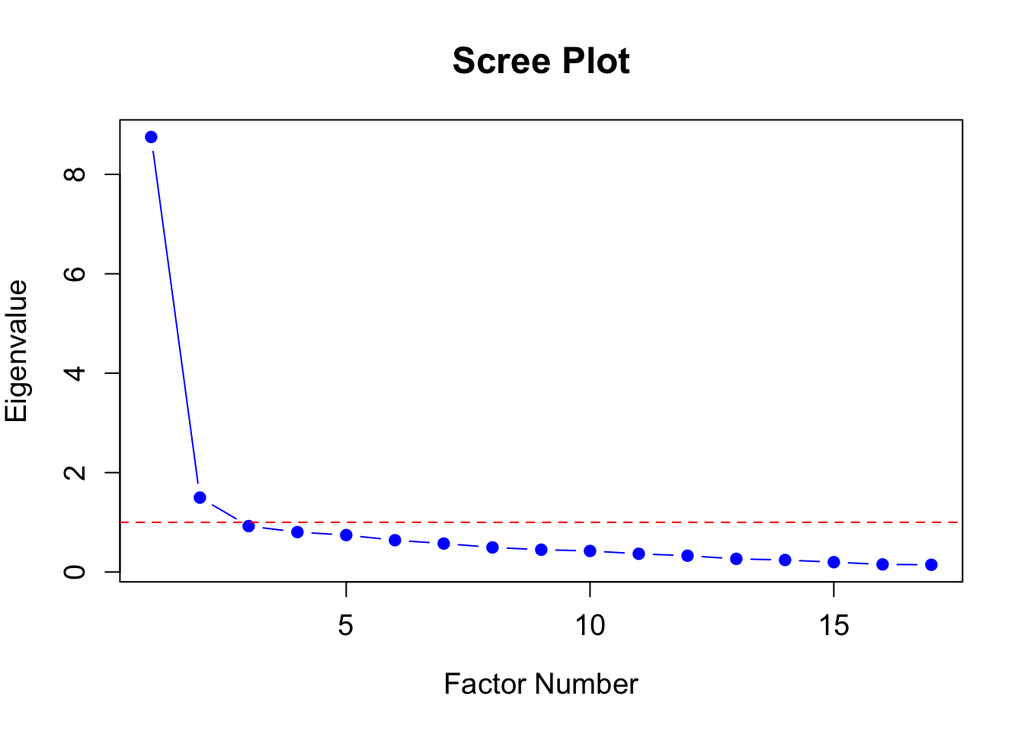

```r
# Eigenvalues extracted from the fitted lavaan EFA model
eigenvalues <- c(8.752, 1.497, 0.924, 0.803, 0.743, 0.640, 0.573, 0.495, 0.449, 0.424, 0.367, 0.328, 0.265, 0.242, 0.198, 0.153, 0.146)

# Create a Scree Plot
plot(eigenvalues, type = "b", pch = 19, main = "Scree Plot",
     xlab = "Factor Number", ylab = "Eigenvalue", col = "blue",
     cex.lab = 1.2, cex.axis = 1.2, cex.main = 1.5)

# Add a reference line at y = 1
abline(h = 1, col = "red", lty = 2)
```

**Click to see full model results:**

```r
# model stats
summary(efa_pai_f)
```

```
##
##   Estimator                                         ML
##   Rotation method                       GEOMIN OBLIQUE
##   Geomin epsilon                                 0.001
##   Rotation algorithm (rstarts)                GPA (30)
##   Standardized metric                             TRUE
##   Row weights                                     None
##
##                                                   Used       Total
##   Number of observations                           166         204
##
## Overview models:
##                     aic      bic    sabic   chisq  df pvalue   cfi rmsea
##   nfactors = 1 3556.658 3662.466 3554.819 456.241 119      0 0.813 0.131
##   nfactors = 2 3425.517 3581.116 3422.812 293.100 103      0 0.894 0.105
##   nfactors = 3 3391.954 3594.233 3388.438 229.537  88      0 0.921 0.098
##
## Eigenvalues correlation matrix:
##
##     ev1     ev2     ev3     ev4     ev5     ev6     ev7     ev8     ev9    ev10
##   8.752   1.497   0.924   0.803   0.743   0.640   0.573   0.495   0.449   0.424
##    ev11    ev12    ev13    ev14    ev15    ev16    ev17
##   0.367   0.328   0.265   0.242   0.198   0.153   0.146
##
## Number of factors:  1
##
## Standardized loadings: (* = significant at 1% level)
##
##               f1       unique.var   communalities
## pai5.2_2   0.803*           0.355           0.645
## pai7.2_2   0.592*           0.650           0.350
## pai9.2_2   0.641*           0.589           0.411
## pai12.2_2  0.760*           0.422           0.578
## pai13.2_2  0.812*           0.341           0.659
## pai14.2_2  0.546*           0.702           0.298
## pai17.2_2  0.640*           0.590           0.410
## pai19.2_2  0.567*           0.678           0.322
## pai20.2_2  0.810*           0.345           0.655
## pai21.2_2  0.746*           0.443           0.557
## pai23.2_2  0.847*           0.283           0.717
```

[output cut: 68 more lines]

```
## pai28.2_2          0.588*      .            0.378           0.622
## pai29.2_2          0.523*  0.310            0.442           0.558
##
##                               f1    f3    f2  total
## Sum of sq (obliq) loadings 4.652 2.981 2.372 10.005
## Proportion of total        0.465 0.298 0.237  1.000
## Proportion var             0.274 0.175 0.140  0.589
## Cumulative var             0.274 0.449 0.589  0.589
##
## Factor correlations: (* = significant at 1% level)
##
##        f1      f2      f3
## f1  1.000
## f2  0.516*  1.000
## f3  0.785*  0.647*  1.000
```

The EFA-suggested 2-factor model does not fit well.

```r
cfa_pai_f <- '
  pai_f1_f_2 =~ pai7.2_2 + pai9.2_2 + pai12.2_2 + pai14.2_2 + pai21.2_2
  pai_f2_f_2 =~ pai13.2_2 + pai17.2_2 + pai24.2_2 + pai26.2_2 + pai28.2_2 + pai29.2_2
'

fit_pai_f <- cfa(cfa_pai_f,
                 data = dat_s,
                 std.lv = TRUE, missing = "FIML",
                 parameterization = "theta"
                 )
```

**Click to see full model results:**

```r
summary(fit_pai_f, fit.measures = TRUE, standardized = TRUE)
```

```
## lavaan 0.6.15 ended normally after 73 iterations
##
##   Estimator                                         ML
##   Optimization method                           NLMINB
##   Number of model parameters                        34
##
##                                                   Used       Total
##   Number of observations                           172         204
##   Number of missing patterns                         3
##
## Model Test User Model:
##
##   Test statistic                               116.334
##   Degrees of freedom                                43
##   P-value (Chi-square)                           0.000
##
## Model Test Baseline Model:
##
##   Test statistic                               965.630
##   Degrees of freedom                                55
##   P-value                                        0.000
##
## User Model versus Baseline Model:
##
##   Comparative Fit Index (CFI)                    0.919
##   Tucker-Lewis Index (TLI)                       0.897
##
##   Robust Comparative Fit Index (CFI)             0.920
##   Robust Tucker-Lewis Index (TLI)                0.898
##
## Loglikelihood and Information Criteria:
##
##   Loglikelihood user model (H0)              -1251.712
##   Loglikelihood unrestricted model (H1)      -1193.545
##
##   Akaike (AIC)                                2571.425
##   Bayesian (BIC)                              2678.440
##   Sample-size adjusted Bayesian (SABIC)       2570.779
##
## Root Mean Square Error of Approximation:
```

[output cut: 60 more lines]

```
## Variances:
##                    Estimate  Std.Err  z-value  P(>|z|)   Std.lv  Std.all
##    .pai7.2_2          0.353    0.041    8.682    0.000    0.353    0.666
##    .pai9.2_2          0.230    0.030    7.654    0.000    0.230    0.427
##    .pai12.2_2         0.155    0.023    6.753    0.000    0.155    0.320
##    .pai14.2_2         0.307    0.036    8.488    0.000    0.307    0.610
##    .pai21.2_2         0.121    0.021    5.752    0.000    0.121    0.248
##    .pai13.2_2         0.051    0.009    5.637    0.000    0.051    0.248
##    .pai17.2_2         0.244    0.029    8.362    0.000    0.244    0.564
##    .pai24.2_2         0.150    0.018    8.499    0.000    0.150    0.613
##    .pai26.2_2         0.166    0.020    8.232    0.000    0.166    0.549
##    .pai28.2_2         0.084    0.011    7.814    0.000    0.084    0.470
##    .pai29.2_2         0.128    0.016    8.114    0.000    0.128    0.529
##     pai_f1_f_2        1.000                               1.000    1.000
##     pai_f2_f_2        1.000                               1.000    1.000
```

```r
# modindices(fit_pai_f, sort = TRUE, maximum.number = 5)
```

The EFA-suggested 3-factor model also does not fit well, even after attempts to remove certain items.

```r
cfa_pai_f <- '
  pai_f1_f_2 =~ pai7.2_2 + pai9.2_2 + pai12.2_2 + pai14.2_2 + pai20.2_2 + pai21.2_2 + pai27.2_2
  pai_f2_f_2 =~ pai19.2_2 + pai28.2_2 + pai29.2_2
  pai_f3_f_2 =~ pai13.2_2 + pai17.2_2 + pai25.2_2 + pai26.2_2
'

fit_pai_f <- cfa(cfa_pai_f,
                 data = dat_s,
                 std.lv = TRUE, missing = "FIML",
                 parameterization = "theta"
                 )
```

**Click to see full model results:**

```r
summary(fit_pai_f, fit.measures = TRUE, standardized = TRUE)
```

```
## lavaan 0.6.15 ended normally after 88 iterations
##
##   Estimator                                         ML
##   Optimization method                           NLMINB
##   Number of model parameters                        45
##
##                                                   Used       Total
##   Number of observations                           172         204
##   Number of missing patterns                         2
##
## Model Test User Model:
##
##   Test statistic                               215.056
##   Degrees of freedom                                74
##   P-value (Chi-square)                           0.000
##
## Model Test Baseline Model:
##
##   Test statistic                              1428.608
##   Degrees of freedom                                91
##   P-value                                        0.000
##
## User Model versus Baseline Model:
##
##   Comparative Fit Index (CFI)                    0.895
##   Tucker-Lewis Index (TLI)                       0.870
##
##   Robust Comparative Fit Index (CFI)             0.893
##   Robust Tucker-Lewis Index (TLI)                0.869
##
## Loglikelihood and Information Criteria:
##
##   Loglikelihood user model (H0)              -1521.167
##   Loglikelihood unrestricted model (H1)      -1413.639
##
##   Akaike (AIC)                                3132.333
##   Bayesian (BIC)                              3273.971
##   Sample-size adjusted Bayesian (SABIC)       3131.478
##
## Root Mean Square Error of Approximation:
```

[output cut: 75 more lines]

```
##    .pai12.2_2         0.152    0.021    7.110    0.000    0.152    0.314
##    .pai14.2_2         0.320    0.037    8.638    0.000    0.320    0.635
##    .pai20.2_2         0.105    0.014    7.396    0.000    0.105    0.366
##    .pai21.2_2         0.162    0.023    7.152    0.000    0.162    0.334
##    .pai27.2_2         0.402    0.046    8.653    0.000    0.402    0.654
##    .pai19.2_2         0.054    0.008    6.749    0.000    0.054    0.398
##    .pai28.2_2         0.060    0.010    5.939    0.000    0.060    0.333
##    .pai29.2_2         0.098    0.015    6.633    0.000    0.098    0.404
##    .pai13.2_2         0.053    0.009    5.988    0.000    0.053    0.262
##    .pai17.2_2         0.234    0.028    8.306    0.000    0.234    0.540
##    .pai25.2_2         0.175    0.023    7.494    0.000    0.175    0.422
##    .pai26.2_2         0.147    0.018    7.979    0.000    0.147    0.485
##     pai_f1_f_2        1.000                               1.000    1.000
##     pai_f2_f_2        1.000                               1.000    1.000
##     pai_f3_f_2        1.000                               1.000    1.000
```

```r
# modindices(fit_pai_f, sort = TRUE, maximum.number = 5)
```

**Reliability:**

```r
get_rel(model = fit_pai_f,
        data = dat_s |> select(pai7.2_2:pai28.2_2))
```

```
## [1] "Cronbach's Alpha is 0.934, which is Excellent; McDonald's Omega is 0.872, which is Good."
## [2] "Cronbach's Alpha is 0.934, which is Excellent; McDonald's Omega is 0.824, which is Good."
## [3] "Cronbach's Alpha is 0.934, which is Excellent; McDonald's Omega is 0.825, which is Good."
```

# 9 RELATIONSHIP QUALITY

The model for mother’s report of relationship quality has good fit (2-factor model with support and abuse as subscales), without any tweaks to the CFA model. However the model for father’s report does not fit well. Modification indices suggest that `rq3` (“He insults or criticizes you or your ideas”) and `rq6` (“He tries to prevent you from going to work or school”) should be loaded on to the support factor, which does not make theoretical sense. Removing `rq3` resulted in a good model fit (perhaps because mothers are less likely).

## 9.1 Mother’s report on how father behaves to her

```r
cfa_rq_m <- '
  rq_support_m_2 =~ rq1.1_2 + rq2.1_2 + rq4.1_2 + rq8.1_2 + rq9.1_2
  rq_abuse_m_2 =~ rq3.1_2 + rq5.1_2 + rq6.1_2 + rq7.1_2
'

fit_rq_m <- cfa(cfa_rq_m,
                 data = dat_s,
                 std.lv = TRUE, missing = "FIML",
                 parameterization = "theta"
                 )
```

**Click to see full model results:**

```r
summary(fit_rq_m, fit.measures = TRUE, standardized = TRUE)
```

```
## lavaan 0.6.15 ended normally after 53 iterations
##
##   Estimator                                         ML
##   Optimization method                           NLMINB
##   Number of model parameters                        28
##
##                                                   Used       Total
##   Number of observations                           201         204
##   Number of missing patterns                         3
##
## Model Test User Model:
##
##   Test statistic                                34.436
##   Degrees of freedom                                26
##   P-value (Chi-square)                           0.124
##
## Model Test Baseline Model:
##
##   Test statistic                               259.334
##   Degrees of freedom                                36
##   P-value                                        0.000
##
## User Model versus Baseline Model:
##
##   Comparative Fit Index (CFI)                    0.962
##   Tucker-Lewis Index (TLI)                       0.948
##
##   Robust Comparative Fit Index (CFI)             0.963
##   Robust Tucker-Lewis Index (TLI)                0.948
##
## Loglikelihood and Information Criteria:
##
##   Loglikelihood user model (H0)               -840.385
##   Loglikelihood unrestricted model (H1)       -823.167
##
##   Akaike (AIC)                                1736.771
##   Bayesian (BIC)                              1829.263
##   Sample-size adjusted Bayesian (SABIC)       1740.555
##
## Root Mean Square Error of Approximation:
```

[output cut: 54 more lines]

```
##     rq_abuse_m_2      0.000                               0.000    0.000
##
## Variances:
##                    Estimate  Std.Err  z-value  P(>|z|)   Std.lv  Std.all
##    .rq1.1_2           0.241    0.025    9.467    0.000    0.241    0.837
##    .rq2.1_2           0.075    0.009    8.287    0.000    0.075    0.648
##    .rq4.1_2           0.105    0.012    8.846    0.000    0.105    0.718
##    .rq8.1_2           0.135    0.016    8.616    0.000    0.135    0.721
##    .rq9.1_2           0.067    0.016    4.267    0.000    0.067    0.339
##    .rq3.1_2           0.286    0.036    7.991    0.000    0.286    0.820
##    .rq5.1_2           0.195    0.024    7.961    0.000    0.195    0.815
##    .rq6.1_2           0.063    0.007    8.749    0.000    0.063    0.881
##    .rq7.1_2           0.076    0.011    7.156    0.000    0.076    0.763
##     rq_support_m_2    1.000                               1.000    1.000
##     rq_abuse_m_2      1.000                               1.000    1.000
```

```r
# modindices(fit_rq_m, sort = TRUE, maximum.number = 5)
```

**Reliability:**

The support subscale has good reliability, but abuse subscale seems to have poor reliability.

```r
semTools::compRelSEM(fit_rq_m)
```

```
## rq_support_m_2   rq_abuse_m_2
##          0.708          0.444
```

```r
psych::alpha(dat_s |> select(rq1.1_2, rq2.1_2, rq4.1_2, rq8.1_2, rq9.1_2), check.keys = TRUE)$total$raw_alpha
```

```
## [1] 0.6872858
```

```r
psych::alpha(dat_s |> select(rq3.1_2, rq5.1_2, rq6.1_2, rq7.1_2), check.keys = TRUE)$total$raw_alpha
```

```
## [1] 0.433775
```

## 9.2 Father’s report on how mother behaves to him

The theory-based model does not fit well.

```r
cfa_rq_f <- '
  rq_support_f_2 =~ rq1.2_2 + rq2.2_2 + rq4.2_2 + rq8.2_2 + rq9.2_2
  rq_abuse_f_2 =~ rq3.2_2 + rq5.2_2 + rq6.2_2 + rq7.2_2
'

fit_rq_f <- cfa(cfa_rq_f,
                 data = dat_s,
                 std.lv = TRUE, missing = "FIML",
                 parameterization = "theta"
                 )
```

**Click to see full model results:**

```r
summary(fit_rq_f, fit.measures = TRUE, standardized = TRUE)
```

```
## lavaan 0.6.15 ended normally after 57 iterations
##
##   Estimator                                         ML
##   Optimization method                           NLMINB
##   Number of model parameters                        28
##
##                                                   Used       Total
##   Number of observations                           173         204
##   Number of missing patterns                         2
##
## Model Test User Model:
##
##   Test statistic                                62.031
##   Degrees of freedom                                26
##   P-value (Chi-square)                           0.000
##
## Model Test Baseline Model:
##
##   Test statistic                               519.563
##   Degrees of freedom                                36
##   P-value                                        0.000
##
## User Model versus Baseline Model:
##
##   Comparative Fit Index (CFI)                    0.925
##   Tucker-Lewis Index (TLI)                       0.897
##
##   Robust Comparative Fit Index (CFI)             0.926
##   Robust Tucker-Lewis Index (TLI)                0.897
##
## Loglikelihood and Information Criteria:
##
##   Loglikelihood user model (H0)               -671.269
##   Loglikelihood unrestricted model (H1)       -640.253
##
##   Akaike (AIC)                                1398.538
##   Bayesian (BIC)                              1486.830
##   Sample-size adjusted Bayesian (SABIC)       1398.166
##
## Root Mean Square Error of Approximation:
```

[output cut: 54 more lines]

```
##     rq_abuse_f_2      0.000                               0.000    0.000
##
## Variances:
##                    Estimate  Std.Err  z-value  P(>|z|)   Std.lv  Std.all
##    .rq1.2_2           0.259    0.028    9.142    0.000    0.259    0.900
##    .rq2.2_2           0.098    0.013    7.568    0.000    0.098    0.447
##    .rq4.2_2           0.071    0.011    6.690    0.000    0.071    0.362
##    .rq8.2_2           0.125    0.016    7.673    0.000    0.125    0.471
##    .rq9.2_2           0.080    0.014    5.698    0.000    0.080    0.291
##    .rq3.2_2           0.252    0.028    9.046    0.000    0.252    0.908
##    .rq5.2_2           0.146    0.023    6.286    0.000    0.146    0.585
##    .rq6.2_2           0.028    0.003    8.760    0.000    0.028    0.807
##    .rq7.2_2           0.031    0.014    2.126    0.034    0.031    0.246
##     rq_support_f_2    1.000                               1.000    1.000
##     rq_abuse_f_2      1.000                               1.000    1.000
```

```r
# modindices(fit_rq_f, sort = TRUE, maximum.number = 5)
```

Leaving out `rq3` (“He insults or criticizes you or your ideas”) results in a good model fit.

```r
cfa_rq_f <- '
  rq_support_f_2 =~ rq1.2_2 + rq2.2_2 + rq4.2_2 + rq8.2_2 + rq9.2_2
  rq_abuse_f_2 =~ rq5.2_2 + rq6.2_2 + rq7.2_2
'

fit_rq_f <- cfa(cfa_rq_f,
                 data = dat_s,
                 std.lv = TRUE, missing = "FIML",
                 parameterization = "theta"
                 )
```

**Click to see full model results:**

```r
summary(fit_rq_f, fit.measures = TRUE, standardized = TRUE)
```

```
## lavaan 0.6.15 ended normally after 55 iterations
##
##   Estimator                                         ML
##   Optimization method                           NLMINB
##   Number of model parameters                        25
##
##                                                   Used       Total
##   Number of observations                           173         204
##   Number of missing patterns                         2
##
## Model Test User Model:
##
##   Test statistic                                33.058
##   Degrees of freedom                                19
##   P-value (Chi-square)                           0.024
##
## Model Test Baseline Model:
##
##   Test statistic                               477.364
##   Degrees of freedom                                28
##   P-value                                        0.000
##
## User Model versus Baseline Model:
##
##   Comparative Fit Index (CFI)                    0.969
##   Tucker-Lewis Index (TLI)                       0.954
##
##   Robust Comparative Fit Index (CFI)             0.969
##   Robust Tucker-Lewis Index (TLI)                0.954
##
## Loglikelihood and Information Criteria:
##
##   Loglikelihood user model (H0)               -543.202
##   Loglikelihood unrestricted model (H1)       -526.673
##
##   Akaike (AIC)                                1136.404
##   Bayesian (BIC)                              1215.237
##   Sample-size adjusted Bayesian (SABIC)       1136.073
##
## Root Mean Square Error of Approximation:
```

[output cut: 51 more lines]

```
##     rq_support_f_2    0.000                               0.000    0.000
##     rq_abuse_f_2      0.000                               0.000    0.000
##
## Variances:
##                    Estimate  Std.Err  z-value  P(>|z|)   Std.lv  Std.all
##    .rq1.2_2           0.260    0.028    9.142    0.000    0.260    0.901
##    .rq2.2_2           0.098    0.013    7.547    0.000    0.098    0.445
##    .rq4.2_2           0.071    0.011    6.688    0.000    0.071    0.362
##    .rq8.2_2           0.125    0.016    7.668    0.000    0.125    0.472
##    .rq9.2_2           0.080    0.014    5.690    0.000    0.080    0.291
##    .rq5.2_2           0.144    0.025    5.661    0.000    0.144    0.577
##    .rq6.2_2           0.027    0.003    8.621    0.000    0.027    0.792
##    .rq7.2_2           0.032    0.016    1.942    0.052    0.032    0.253
##     rq_support_f_2    1.000                               1.000    1.000
##     rq_abuse_f_2      1.000                               1.000    1.000
```

```r
# modindices(fit_rq_f, sort = TRUE, maximum.number = 5)
```

**Reliability:**

```r
semTools::compRelSEM(fit_rq_f)
```

```
## rq_support_f_2   rq_abuse_f_2
##          0.824          0.714
```

```r
psych::alpha(dat_s |> select(rq1.2_2, rq2.2_2, rq4.2_2, rq8.2_2, rq9.2_2), check.keys = TRUE)$total$raw_alpha
```

```
## [1] 0.8004395
```

```r
psych::alpha(dat_s |> select(rq3.2_2, rq5.2_2, rq6.2_2, rq7.2_2), check.keys = TRUE)$total$raw_alpha
```

```
## [1] 0.5539115
```

# 10 CONFLICT TACTICS SCALE

For this measure, the CFA models also failed to build due to highly skewed data. As suggested by Aaron, there are usually pairs items measuring the instance of behaviors of the same nature, and we can simply average the two item scores within each subscale:

**_self: I did … to my partner.**

**_partner: My partner did … to me**

```r
"
# compromise and show respect
cts_compromise_self =~ cts1 + cts7
cts_compromise_partner =~ cts2 + cts8

# verbal abuse (and also destroy other's belonging)
cts_verbal_abuse_self =~ cts3 + cts13
cts_verbal_abuse_partner =~ cts4 + cts14

# physical injury as a result of an argument/fight
cts_injury_self =~ cts5 + cts15
cts_injury_partner =~ cts6 + cts16

# physical abuse
cts_phyiscal_abuse_self =~ cts9 + cts11
cts_phyiscal_abuse_partner =~ cts10 + cts12

# sexual abuse
cts_sex_abuse_self =~ cts17 + cts19
cts_sex_abuse_partner =~ cts18 + cts20
"
```